# **Seoul Bike Sharing Demand Prediction**

## **Spring 2024 Data Science Project Contributions**

Member 1: Ashley Chung, Contribution: 100%. Member 2: William Chan, Contribution: 95% (did not contribute to H). Member 3: John Shim, Contribution: 95% (did not contribute to H).

"We, all Ashley Chung, William Chan, and John Shim, agree together that the above information is true, and we are confident about our contributions to this submitted project/final tutorial."

## **Contribution Specifics**

Ashley Chung - 5/06/2024 Cleaned Functioning Day and Date columns, some summary statistics, outliers visualizations, relationship between seasons and rented bike count, feature engineering (including the hot encoding that was used for all three regression models), the designing, development, training, and testing of linear regression, some insights and conclusions, some tutorial instructions throughout.

William Chan - 5/06/2024 I helped in coming up with our over represented features and creating different visualizations for some of the summary statistics. Contributed to some of the conclusions we drew from our summary statistics. I also came up with an idea to use a Mann-Whitney test to see if the median rented bike count is the same during daytime and nighttime hours. Helped contribute to the tutorial instructions for all our different sections.

John Shim - 5/06/2024 I found the Seoul Bike Sharing Demand dataset on Kaggle and shared the idea with my group. I worked with everyone on the portion of the data cleaning where I hot encoded the column, 'Functioning Days' from Yes and No to 1s and 0s. I then implemented the protion of the summary statistics that used the describe() function. I also drew the histograms of rented bike hours vs rainy hours, non-rainy hours, snowy hours, and non-snowy hours. I worked on the section of the hypothesis testing, Relationship Between Rented Bike Count and Visibility where I did a Mann-Whitney test testing The number of rented bikes per hour under normal visibility vs low visibility. In this section I also drew boxplots and violin plots to visualize rented bike count by visibility. I designed, developed, trained, and test the random forest and gradient boosting regression models. I also worked on portions of the conclusion that explained insights on the results of the two models.

**William Chan, Ashley Chung, John Shim**

# **0. Introduction**

In large cities across the world, many people use bikes as their method of transportation. Biking can help people skip heavy city traffic, is better for the environment, and is a great form of exercise. This is no exception in Seoul, South Korea. Seoul has a bike sharing program called Ttareungi where anyone can rent bikes. Its usage is about 52,000 trips per day on average, which would include both recreational use and commuting. Seoul also has encouraged residents and tourists to use bikes. Their city includes over 900 km of bike lanes and over 145,000 bike racks to make biking safer and more convenient for everyone. The main purpose of this project is to determine how different factors affect the number of rented bikes in Seoul, South Korea and to provide a way to predict the demand. We have gathered a dataset from Kaggle and implemented our own analysis and machine learning techniques to draw conclusions about what affects the rented bike count in Seoul.

This is important to answer because biking is a huge part of the lifestyle in Seoul. The bike share program will need to be as efficient as possible so that anyone in Seoul will be able to easily rent a bike without any inconveniences. By analyzing the different factors that affect the rented bike count, we will be able to predict things such as whether a certain day will have a lot of rented bikes or not. Using this, you could see what conditions in Seoul have a high rented bike count and prepare more bikes in advance so nobody is left without one.

During this tutorial, we will be going through each step we took when analyzing our topic:

1. Data Collection
2. Data Preprocessing
3. Exploratory Analysis
4. Primary Analysis
5. Insights and Conclusions

# **1. Data Collection**

The first step we took is finding a dataset that is relevant to the topic we are looking for. Kaggle is an online platform that has a wide variety of datasets for many different topics. We were able to download the dataset, which was a .csv file that included data on rented bike count in Seoul from December 1, 2017 to November 30, 2018. Each row represents one hour of data which includes the number of rented bikes, temperature statistics, what season that date represents, etc. Download the dataset [here](https://www.kaggle.com/datasets/saurabhshahane/seoul-bike-sharing-demand-prediction/code) and import into Google Colab.

# **2. Data Preprocessing**

```python
!pip install scikit-posthocs
import pandas as pd
import numpy as np
import matplotlib.pyplot as plt
import scikit_posthocs as sp
import seaborn as sns
from scipy import stats
from sklearn.model_selection import train_test_split
from sklearn.preprocessing import StandardScaler
from sklearn.linear_model import LinearRegression
from sklearn.ensemble import RandomForestRegressor
from sklearn.ensemble import GradientBoostingRegressor
from sklearn.metrics import mean_squared_error, r2_score
```

First off, let's read csv file and see what our dataframe looks like.

```python
df = pd.read_csv('SeoulBikeData.csv', encoding= 'unicode_escape')
df.head(5)
```

|  | Date | Rented Bike Count | Hour | Temperature(°C) | Humidity(%) | Wind speed (m/s) | Visibility (10m) | Dew point temperature(°C) | Solar Radiation (MJ/m2) | Rainfall(mm) | Snowfall (cm) | Seasons | Holiday | Functioning Day |
| --- | --- | --- | --- | --- | --- | --- | --- | --- | --- | --- | --- | --- | --- | --- |
| 0 | 01/12/2017 | 254 | 0 | -5.2 | 37 | 2.2 | 2000 | -17.6 | 0.0 | 0.0 | 0.0 | Winter | No Holiday | Yes |
| 1 | 01/12/2017 | 204 | 1 | -5.5 | 38 | 0.8 | 2000 | -17.6 | 0.0 | 0.0 | 0.0 | Winter | No Holiday | Yes |
| 2 | 01/12/2017 | 173 | 2 | -6.0 | 39 | 1.0 | 2000 | -17.7 | 0.0 | 0.0 | 0.0 | Winter | No Holiday | Yes |
| 3 | 01/12/2017 | 107 | 3 | -6.2 | 40 | 0.9 | 2000 | -17.6 | 0.0 | 0.0 | 0.0 | Winter | No Holiday | Yes |
| 4 | 01/12/2017 | 78 | 4 | -6.0 | 36 | 2.3 | 2000 | -18.6 | 0.0 | 0.0 | 0.0 | Winter | No Holiday | Yes |

The data itself is pretty clean, so we don’t need to make too many adjustments. Looking through all the entries, there are no null values or duplicated rows that need to be taken care of.

```python
print("Number of null entries per column:\n")
df.isna().sum()
```

```
Number of null entries per column:
```

```
Date                         0
Rented Bike Count            0
Hour                         0
Temperature(°C)              0
Humidity(%)                  0
Wind speed (m/s)             0
Visibility (10m)             0
Dew point temperature(°C)    0
Solar Radiation (MJ/m2)      0
Rainfall(mm)                 0
Snowfall (cm)                0
Seasons                      0
Holiday                      0
Functioning Day              0
dtype: int64
```

```python
print("Number of duplicate entries:", len(df[df.duplicated()]))
```

```
Number of duplicate entries: 0
```

One of the columns in our dataset indicated whether that day was a functioning day or not. Our primary interest is the Rented Bike Count column. Since it is obvious that no bikes will be rented out on non-functioning days, let’s drop that column as there’s nothing to really analyze there.

```python
display(df.groupby('Functioning Day').sum(numeric_only=True)['Rented Bike Count'].reset_index())
df = df.drop(df[df['Functioning Day'] == 'No'].index)
df = df.drop(['Functioning Day'], axis = 1)
```

|  | Functioning Day | Rented Bike Count |
| --- | --- | --- |
| 0 | No | 0 |
| 1 | Yes | 6172314 |

We’re also going to break down the Date column into multiple new columns: Year, Month, Day, and Weekday. Year, month, and day will represent the actual date and weekday will tell us the day of the week (Monday, Tuesday, etc.). This will help when we’re trying to find the relationship between these new features and rented bike count when doing our analysis. Finally, we can drop the old Date column since it will include redundant information in our new columns.

```python
df['Date'] = pd.to_datetime(df['Date'], dayfirst=True)

df['Year'] = df['Date'].dt.year
df['Month'] = df['Date'].dt.month
df['Day'] = df['Date'].dt.day
df['Weekday'] = df['Date'].dt.day_name()

df = df.drop(['Date'], axis=1)
```

Here's a peek at our dataset after cleaning the data:

```python
df.head(5)
```

|  | Rented Bike Count | Hour | Temperature(°C) | Humidity(%) | Wind speed (m/s) | Visibility (10m) | Dew point temperature(°C) | Solar Radiation (MJ/m2) | Rainfall(mm) | Snowfall (cm) | Seasons | Holiday | Year | Month | Day | Weekday |
| --- | --- | --- | --- | --- | --- | --- | --- | --- | --- | --- | --- | --- | --- | --- | --- | --- |
| 0 | 254 | 0 | -5.2 | 37 | 2.2 | 2000 | -17.6 | 0.0 | 0.0 | 0.0 | Winter | No Holiday | 2017 | 12 | 1 | Friday |
| 1 | 204 | 1 | -5.5 | 38 | 0.8 | 2000 | -17.6 | 0.0 | 0.0 | 0.0 | Winter | No Holiday | 2017 | 12 | 1 | Friday |
| 2 | 173 | 2 | -6.0 | 39 | 1.0 | 2000 | -17.7 | 0.0 | 0.0 | 0.0 | Winter | No Holiday | 2017 | 12 | 1 | Friday |
| 3 | 107 | 3 | -6.2 | 40 | 0.9 | 2000 | -17.6 | 0.0 | 0.0 | 0.0 | Winter | No Holiday | 2017 | 12 | 1 | Friday |
| 4 | 78 | 4 | -6.0 | 36 | 2.3 | 2000 | -18.6 | 0.0 | 0.0 | 0.0 | Winter | No Holiday | 2017 | 12 | 1 | Friday |

# **3. Exploratory Analysis**

## **Summary Statistics**

In our exploratory analysis, we’re going to present conclusions based on different statistical methods. First, let’s look at some of the summary statistics of our data.

```python
print("Number of rows:", len(df))
print("Number of columns:", len(df.columns))
```

```
Number of rows: 8465
Number of columns: 16
```

```python
list(df.columns)
```

```
['Rented Bike Count',
 'Hour',
 'Temperature(°C)',
 'Humidity(%)',
 'Wind speed (m/s)',
 'Visibility (10m)',
 'Dew point temperature(°C)',
 'Solar Radiation (MJ/m2)',
 'Rainfall(mm)',
 'Snowfall (cm)',
 'Seasons',
 'Holiday',
 'Year',
 'Month',
 'Day',
 'Weekday']
```

```python
df.dtypes
```

```
Rented Bike Count              int64
Hour                           int64
Temperature(°C)              float64
Humidity(%)                    int64
Wind speed (m/s)             float64
Visibility (10m)               int64
Dew point temperature(°C)    float64
Solar Radiation (MJ/m2)      float64
Rainfall(mm)                 float64
Snowfall (cm)                float64
Seasons                       object
Holiday                       object
Year                           int32
Month                          int32
Day                            int32
Weekday                       object
dtype: object
```

```python
df.describe().T
```

|  | count | mean | std | min | 25% | 50% | 75% | max |
| --- | --- | --- | --- | --- | --- | --- | --- | --- |
| Rented Bike Count | 8465.0 | 729.156999 | 642.351166 | 2.0 | 214.0 | 542.00 | 1084.00 | 3556.00 |
| Hour | 8465.0 | 11.507029 | 6.920899 | 0.0 | 6.0 | 12.00 | 18.00 | 23.00 |
| Temperature(°C) | 8465.0 | 12.771057 | 12.104375 | -17.8 | 3.0 | 13.50 | 22.70 | 39.40 |
| Humidity(%) | 8465.0 | 58.147194 | 20.484839 | 0.0 | 42.0 | 57.00 | 74.00 | 98.00 |
| Wind speed (m/s) | 8465.0 | 1.725883 | 1.034281 | 0.0 | 0.9 | 1.50 | 2.30 | 7.40 |
| Visibility (10m) | 8465.0 | 1433.873479 | 609.051229 | 27.0 | 935.0 | 1690.00 | 2000.00 | 2000.00 |
| Dew point temperature(°C) | 8465.0 | 3.944997 | 13.242399 | -30.6 | -5.1 | 4.70 | 15.20 | 27.20 |
| Solar Radiation (MJ/m2) | 8465.0 | 0.567868 | 0.868245 | 0.0 | 0.0 | 0.01 | 0.93 | 3.52 |
| Rainfall(mm) | 8465.0 | 0.149120 | 1.125540 | 0.0 | 0.0 | 0.00 | 0.00 | 35.00 |
| Snowfall (cm) | 8465.0 | 0.077685 | 0.444063 | 0.0 | 0.0 | 0.00 | 0.00 | 8.80 |
| Year | 8465.0 | 2017.912109 | 0.283154 | 2017.0 | 2018.0 | 2018.00 | 2018.00 | 2018.00 |
| Month | 8465.0 | 6.438984 | 3.452362 | 1.0 | 3.0 | 6.00 | 9.00 | 12.00 |
| Day | 8465.0 | 15.840992 | 8.767785 | 1.0 | 8.0 | 16.00 | 23.00 | 31.00 |

```python
df['Seasons'].value_counts().reindex(['Spring', 'Summer', 'Autumn', 'Winter'])
```

```
Seasons
Spring    2160
Summer    2208
Autumn    1937
Winter    2160
Name: count, dtype: int64
```

## **Correlation**

We can also see different statistics for each of our columns/features and how they’re correlated with one another.

```python
df.corr(numeric_only=True)
```

|  | Rented Bike Count | Hour | Temperature(°C) | Humidity(%) | Wind speed (m/s) | Visibility (10m) | Dew point temperature(°C) | Solar Radiation (MJ/m2) | Rainfall(mm) | Snowfall (cm) | Year | Month | Day |
| --- | --- | --- | --- | --- | --- | --- | --- | --- | --- | --- | --- | --- | --- |
| Rented Bike Count | 1.000000 | 0.425256 | 0.562740 | -0.201973 | 0.125022 | 0.212323 | 0.400263 | 0.273862 | -0.128626 | -0.151611 | 0.232004 | 0.167186 | 0.007644 |
| Hour | 0.425256 | 1.000000 | 0.122742 | -0.235937 | 0.287780 | 0.103869 | 0.004691 | 0.144658 | 0.014345 | -0.022082 | 0.000315 | 0.001048 | -0.001140 |
| Temperature(°C) | 0.562740 | 0.122742 | 1.000000 | 0.166425 | -0.038481 | 0.028262 | 0.914467 | 0.354844 | 0.052149 | -0.217746 | 0.377003 | 0.213947 | 0.014461 |
| Humidity(%) | -0.201973 | -0.235937 | 0.166425 | 1.000000 | -0.337352 | -0.548542 | 0.539402 | -0.457273 | 0.236917 | 0.110127 | 0.035188 | 0.139090 | -0.024615 |
| Wind speed (m/s) | 0.125022 | 0.287780 | -0.038481 | -0.337352 | 1.000000 | 0.180428 | -0.177170 | 0.326222 | -0.024931 | -0.003789 | -0.003568 | -0.154149 | -0.033204 |
| Visibility (10m) | 0.212323 | 0.103869 | 0.028262 | -0.548542 | 0.180428 | 1.000000 | -0.182586 | 0.153046 | -0.170352 | -0.122860 | 0.051802 | 0.063474 | -0.115933 |
| Dew point temperature(°C) | 0.400263 | 0.004691 | 0.914467 | 0.539402 | -0.177170 | -0.182586 | 1.000000 | 0.098525 | 0.126812 | -0.149760 | 0.334985 | 0.239406 | 0.000784 |
| Solar Radiation (MJ/m2) | 0.273862 | 0.144658 | 0.354844 | -0.457273 | 0.326222 | 0.153046 | 0.098525 | 1.000000 | -0.074157 | -0.073380 | 0.130141 | -0.028675 | -0.001724 |
| Rainfall(mm) | -0.128626 | 0.014345 | 0.052149 | 0.236917 | -0.024931 | -0.170352 | 0.126812 | -0.074157 | 1.000000 | 0.008604 | 0.028228 | 0.010912 | 0.000455 |
| Snowfall (cm) | -0.151611 | -0.022082 | -0.217746 | 0.110127 | -0.003789 | -0.122860 | -0.149760 | -0.073380 | 0.008604 | 1.000000 | -0.205030 | 0.058410 | 0.101834 |
| Year | 0.232004 | 0.000315 | 0.377003 | 0.035188 | -0.003568 | 0.051802 | 0.334985 | 0.130141 | 0.028228 | -0.205030 | 1.000000 | -0.500050 | -0.005630 |
| Month | 0.167186 | 0.001048 | 0.213947 | 0.139090 | -0.154149 | 0.063474 | 0.239406 | -0.028675 | 0.010912 | 0.058410 | -0.500050 | 1.000000 | 0.026912 |
| Day | 0.007644 | -0.001140 | 0.014461 | -0.024615 | -0.033204 | -0.115933 | 0.000784 | -0.001724 | 0.000455 | 0.101834 | -0.005630 | 0.026912 | 1.000000 |

- We consider any value of less than or equal to -0.5 or greater than or equal to 0.5 to be strong correlation.
- We are interested in the correlations between Rented Bike Count and the other variables.
- We can see that Rented Bike Count and Temperature has a strong positive correlation. This means as temperature increases, the number of rented bikes will usually increase as well.
- We can also see that Rented Bike Count and Hour has a somewhat strong positive correlation. This implies that the later in the day it is, the number of rented bikes tends to increase.
- When looking at the other columns' correlations with Rented Bike Count, none of them really have a strong relationship, but this does not imply that they do not affect Rented Bike Count collectively.

## **Outliers**

Whenever handling data, you have to recognize how to deal with outliers. Let’s create some visualizations for the outliers in our data.

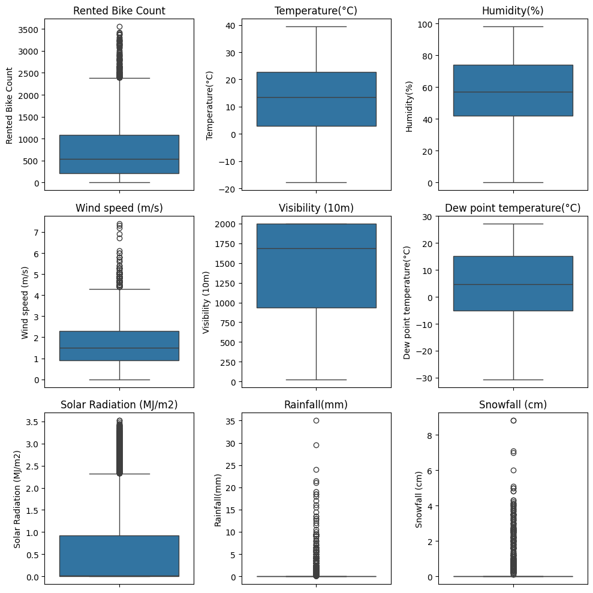

```python
n = 1
plt.figure(figsize=(10,10))

numerical_columns = df[['Rented Bike Count',
                        'Temperature(°C)',
                        'Humidity(%)',
                        'Wind speed (m/s)',
                        'Visibility (10m)',
                        'Dew point temperature(°C)',
                        'Solar Radiation (MJ/m2)',
                        'Rainfall(mm)',
                        'Snowfall (cm)']]

for col in numerical_columns.columns:
  plt.subplot(3,3,n)
  n=n+1
  sns.boxplot(df[col])
  plt.title(col)
  plt.tight_layout()
```

There are many outliers in the box plots for Rented Bike Count, Wind Speed, and Solar Radiation. However, they are representative of what occurs frequently in reality, so they are useful pieces of data. We will not worry about handling them. In particular, Rented Bike Count likely has many outliers because there are certain peak hours at which customers will rent bikes compared to other hours, which we will show later.

The reason why there are so many outliers in rainfall and snowfall is because most days there is no rainfall or snowfall so their box plots heavily centered around 0 or a value that is very close to 0.

## **Over-Represented Features**

It's also important to recognize the over-presented features in your data. These are certain values that appear a lot more than others in the dataset, particularly for the Rainfall and Snowfall columns. Let's create some visualizations for these features.

```python
wet_hours = len(df[df['Rainfall(mm)'] > 0].index)
dry_hours = len(df[df['Rainfall(mm)'] == 0].index)
print("Number of Hours with Rain:", wet_hours)
print("Number of Hours with No Rain:", dry_hours)

snow_hours = len(df[df['Snowfall (cm)'] > 0].index)
non_snow_hours = len(df[df['Snowfall (cm)'] == 0].index)
print("Number of Hours with Snow:", snow_hours)
print("Number of Hours with No Snow:", non_snow_hours)
```

```
Number of Hours with Rain: 516
Number of Hours with No Rain: 7949
Number of Hours with Snow: 443
Number of Hours with No Snow: 8022
```

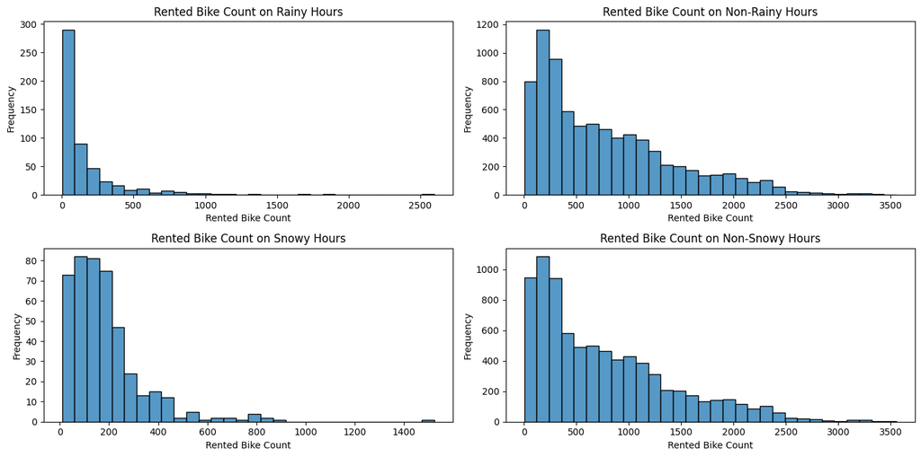

```python
rainy = df[df['Rainfall(mm)'] > 0]
dry = df[df['Rainfall(mm)'] == 0]
snowy = df[df['Snowfall (cm)'] > 0]
non_snowy = df[df['Snowfall (cm)'] == 0]

plt.figure(figsize=(14, 7))

plt.subplot(2, 2, 1)
sns.histplot(rainy['Rented Bike Count'], kde=False, bins=30)
plt.title('Rented Bike Count on Rainy Hours')
plt.xlabel('Rented Bike Count')
plt.ylabel('Frequency')

plt.subplot(2, 2, 2)
sns.histplot(dry['Rented Bike Count'], kde=False, bins=30)
plt.title('Rented Bike Count on Non-Rainy Hours')
plt.xlabel('Rented Bike Count')
plt.ylabel('Frequency')

plt.subplot(2, 2, 3)
sns.histplot(snowy['Rented Bike Count'], kde=False, bins=30)
plt.title('Rented Bike Count on Snowy Hours')
plt.xlabel('Rented Bike Count')
plt.ylabel('Frequency')

plt.subplot(2, 2, 4)
sns.histplot(non_snowy['Rented Bike Count'], kde=False, bins=30)
plt.title('Rented Bike Count on Non-Snowy Hours')
plt.xlabel('Rented Bike Count')
plt.ylabel('Frequency')

plt.tight_layout()
plt.show()
```

Most of the hours (rows) in our dataset don't have any rain or snow. This means that hours with no rain are overrepresented compared to days with rain and that hours with no snow are overrepresented compared to days with snow.

Now we can start using statistical methods to analyze the relationships between Rented Bike Count and other attributes.

## **Relationship Between Seasons and Rented Bike Count**

For our first statistical method, we are going to conduct a Kruskal-Wallis test to show the relationship between seasons and rented bike count.

### **Kruskal-Wallis Test (a = 0.05)**

Ho: Median rented bike count per hour is equal across all seasons

Ha: At least one season has a different median rented bike count per hour compared to the other seasons.

```python
kruskal_results = stats.kruskal(df[df['Seasons'] == 'Spring']['Rented Bike Count'],
                                df[df['Seasons'] == 'Summer']['Rented Bike Count'],
                                df[df['Seasons'] == 'Autumn']['Rented Bike Count'],
                                df[df['Seasons'] == 'Winter']['Rented Bike Count'])

print("Spring median:", df[df['Seasons'] == 'Spring']['Rented Bike Count'].median())
print("Summer median:", df[df['Seasons'] == 'Summer']['Rented Bike Count'].median())
print("Autumn median:", df[df['Seasons'] == 'Autumn']['Rented Bike Count'].median())
print("Winter median:", df[df['Seasons'] == 'Winter']['Rented Bike Count'].median())
print("Kruskal-Wallis p-value:", kruskal_results.pvalue)
```

```
Spring median: 599.0
Summer median: 905.5
Autumn median: 856.0
Winter median: 203.0
Kruskal-Wallis p-value: 0.0
```

Since the p-value (around 0.0, very small) is less than the significance level a (0.05), we can reject the null hypothesis. This means that there is strong evidence for the idea that at least one season has a different median rented bike count per hour compared to the other seasons.

From our Kruskal-Wallis test, we can then apply a Post Hoc Dunn’s Test to see if any two seasons have the same median rented bike count.

### **Post Hoc Dunn's Test for Kruskal-Wallis**

```python
data = [df[df['Seasons'] == 'Spring']['Rented Bike Count'],
        df[df['Seasons'] == 'Summer']['Rented Bike Count'],
        df[df['Seasons'] == 'Autumn']['Rented Bike Count'],
        df[df['Seasons'] == 'Winter']['Rented Bike Count']]

dunn_results = sp.posthoc_dunn(data).applymap(lambda x: f'{x:.4f}')
print(dunn_results)
```

```
        1       2       3       4
1  1.0000  0.0000  0.0000  0.0000
2  0.0000  1.0000  0.0001  0.0000
3  0.0000  0.0001  1.0000  0.0000
4  0.0000  0.0000  0.0000  1.0000
```

No two different seasons have the same median rented bike count because no two seasons have a p-value that is greater than the significance level of 0.05.

Let’s make some visuals to see that the rented bike counts across the four different seasons are indeed different.

### **Visualizations**

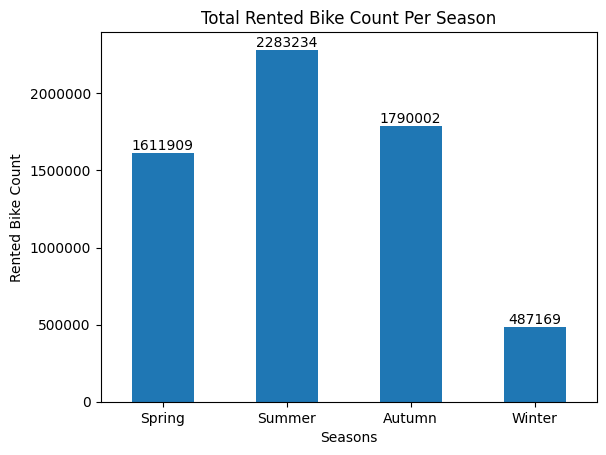

```python
count_per_season = df.groupby('Seasons')['Rented Bike Count'].sum().reindex(['Spring', 'Summer', 'Autumn', 'Winter'])
count_per_season.plot(kind='bar')
plt.title('Total Rented Bike Count Per Season')
plt.xlabel('Seasons')
plt.ylabel('Rented Bike Count')
plt.xticks(rotation=0)
plt.ticklabel_format(style='plain', axis='y')
for index, value in enumerate(count_per_season):
    plt.text(index, value, str(value), ha='center', va='bottom')
plt.show()
```

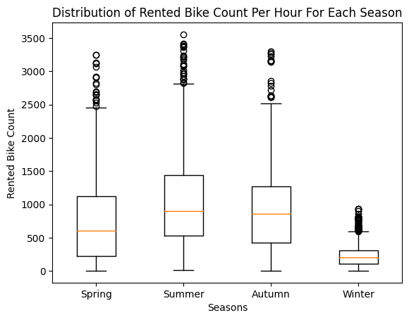

```python
plt.boxplot([df[df['Seasons'] == 'Spring']['Rented Bike Count'],
             df[df['Seasons'] == 'Summer']['Rented Bike Count'],
             df[df['Seasons'] == 'Autumn']['Rented Bike Count'],
             df[df['Seasons'] == 'Winter']['Rented Bike Count']],
            labels=['Spring', 'Summer', 'Autumn', 'Winter'])
plt.title('Distribution of Rented Bike Count Per Hour For Each Season')
plt.xlabel('Seasons')
plt.ylabel('Rented Bike Count')
plt.show()
```

Next, we will conduct a Mann-Whitney U Test and a Kruskal-Wallis Test to show the relationship between retained bike count and the hour of the day.

## **Relationship Between Rented Bike Count and Hours**

### **Mann-Whitney U Test (a = 0.05)**

Ho: The median rented bike count during daytime hours (7AM - 6:59PM) is the same as the median rented bike count during night time hours (7PM - 6:59AM).

Ha: The median rented bike count during daytime hours is different than the median rented bike count during night time hours.

```python
daytime = df[(df['Hour'] >= 7) & (df['Hour'] < 19)]['Rented Bike Count']
nighttime = df[(df['Hour'] >= 19) | (df['Hour'] < 7)]['Rented Bike Count']
res = stats.mannwhitneyu(daytime, nighttime)

print("Daytime median:", daytime.median())
print("Nighttime median:", nighttime.median())
print("p-value:", res.pvalue)
```

```
Daytime median: 761.0
Nighttime median: 326.0
p-value: 8.443038465173174e-131
```

Since the p-value < 0.05, we reject the null hypothesis. This means that the median rented bike count during daytime hours is different than the median rented bike count during night time hours.

### **Kruskal-Wallis Test (a = 0.05)**

Ho: Median rented bike count is equal across all hours

Ha: At least one hour has a different median rented bike count compared to the other hours.

```python
from scipy.stats import kruskal

bike_counts_by_hour = [df[df['Hour'] == hour]['Rented Bike Count'] for hour in range(24)]

stat, p = kruskal(*bike_counts_by_hour)

print(f'Kruskal-Wallis H statistic: {stat}')
print(f'p-value: {p}')
```

```
Kruskal-Wallis H statistic: 2610.4900235657055
p-value: 0.0
```

The Kruskal-Wallis test yielded a p-value of approximately 0.0, so we can reject the null hypothesis, suggesting that there are statistically significant differences in the median rented bike counts across the 24 hours of the day. This indicates that the number of bike rentals is not uniform throughout the day, and certain hours exhibit significantly different bike rental counts compared to others.

Using our Kruskal-Wallis test, we can conduct another Post Hoc Dunn’s Test to see what pairs of hairs don’t have a significantly median rented bike count.

### **Post Hoc Dunn's Test for Kruskal-Wallis**

```python
dunn_results = sp.posthoc_dunn(bike_counts_by_hour).applymap(lambda x: f'{x:.4f}')
dunn_df = pd.DataFrame(dunn_results)
dunn_df.columns = dunn_df.columns - 1
dunn_df.index = dunn_df.index - 1
dunn_df
```

|  | 0 | 1 | 2 | 3 | 4 | 5 | 6 | 7 | 8 | 9 | ... | 14 | 15 | 16 | 17 | 18 | 19 | 20 | 21 | 22 | 23 |
| --- | --- | --- | --- | --- | --- | --- | --- | --- | --- | --- | --- | --- | --- | --- | --- | --- | --- | --- | --- | --- | --- |
| 0 | 1.0000 | 0.0034 | 0.0000 | 0.0000 | 0.0000 | 0.0000 | 0.0000 | 0.4319 | 0.0000 | 0.0059 | ... | 0.0000 | 0.0000 | 0.0000 | 0.0000 | 0.0000 | 0.0000 | 0.0000 | 0.0000 | 0.0000 | 0.0127 |
| 1 | 0.0034 | 1.0000 | 0.0001 | 0.0000 | 0.0000 | 0.0000 | 0.0000 | 0.0002 | 0.0000 | 0.0000 | ... | 0.0000 | 0.0000 | 0.0000 | 0.0000 | 0.0000 | 0.0000 | 0.0000 | 0.0000 | 0.0000 | 0.0000 |
| 2 | 0.0000 | 0.0001 | 1.0000 | 0.0001 | 0.0000 | 0.0000 | 0.3711 | 0.0000 | 0.0000 | 0.0000 | ... | 0.0000 | 0.0000 | 0.0000 | 0.0000 | 0.0000 | 0.0000 | 0.0000 | 0.0000 | 0.0000 | 0.0000 |
| 3 | 0.0000 | 0.0000 | 0.0001 | 1.0000 | 0.0005 | 0.0020 | 0.0034 | 0.0000 | 0.0000 | 0.0000 | ... | 0.0000 | 0.0000 | 0.0000 | 0.0000 | 0.0000 | 0.0000 | 0.0000 | 0.0000 | 0.0000 | 0.0000 |
| 4 | 0.0000 | 0.0000 | 0.0000 | 0.0005 | 1.0000 | 0.7083 | 0.0000 | 0.0000 | 0.0000 | 0.0000 | ... | 0.0000 | 0.0000 | 0.0000 | 0.0000 | 0.0000 | 0.0000 | 0.0000 | 0.0000 | 0.0000 | 0.0000 |
| 5 | 0.0000 | 0.0000 | 0.0000 | 0.0020 | 0.7083 | 1.0000 | 0.0000 | 0.0000 | 0.0000 | 0.0000 | ... | 0.0000 | 0.0000 | 0.0000 | 0.0000 | 0.0000 | 0.0000 | 0.0000 | 0.0000 | 0.0000 | 0.0000 |
| 6 | 0.0000 | 0.0000 | 0.3711 | 0.0034 | 0.0000 | 0.0000 | 1.0000 | 0.0000 | 0.0000 | 0.0000 | ... | 0.0000 | 0.0000 | 0.0000 | 0.0000 | 0.0000 | 0.0000 | 0.0000 | 0.0000 | 0.0000 | 0.0000 |
| 7 | 0.4319 | 0.0002 | 0.0000 | 0.0000 | 0.0000 | 0.0000 | 0.0000 | 1.0000 | 0.0000 | 0.0491 | ... | 0.0000 | 0.0000 | 0.0000 | 0.0000 | 0.0000 | 0.0000 | 0.0000 | 0.0000 | 0.0000 | 0.0880 |
| 8 | 0.0000 | 0.0000 | 0.0000 | 0.0000 | 0.0000 | 0.0000 | 0.0000 | 0.0000 | 1.0000 | 0.0000 | ... | 0.0140 | 0.1749 | 0.9768 | 0.0106 | 0.0000 | 0.0264 | 0.6078 | 0.8043 | 0.3525 | 0.0000 |
| 9 | 0.0059 | 0.0000 | 0.0000 | 0.0000 | 0.0000 | 0.0000 | 0.0000 | 0.0491 | 0.0000 | 1.0000 | ... | 0.0197 | 0.0006 | 0.0000 | 0.0000 | 0.0000 | 0.0000 | 0.0000 | 0.0000 | 0.0001 | 0.7936 |
| 10 | 0.9028 | 0.0050 | 0.0000 | 0.0000 | 0.0000 | 0.0000 | 0.0000 | 0.3635 | 0.0000 | 0.0040 | ... | 0.0000 | 0.0000 | 0.0000 | 0.0000 | 0.0000 | 0.0000 | 0.0000 | 0.0000 | 0.0000 | 0.0089 |
| 11 | 0.0691 | 0.0000 | 0.0000 | 0.0000 | 0.0000 | 0.0000 | 0.0000 | 0.3020 | 0.0000 | 0.3496 | ... | 0.0011 | 0.0000 | 0.0000 | 0.0000 | 0.0000 | 0.0000 | 0.0000 | 0.0000 | 0.0000 | 0.5005 |
| 12 | 0.0001 | 0.0000 | 0.0000 | 0.0000 | 0.0000 | 0.0000 | 0.0000 | 0.0014 | 0.0004 | 0.2193 | ... | 0.2699 | 0.0276 | 0.0003 | 0.0000 | 0.0000 | 0.0000 | 0.0000 | 0.0001 | 0.0085 | 0.1362 |
| 13 | 0.0000 | 0.0000 | 0.0000 | 0.0000 | 0.0000 | 0.0000 | 0.0000 | 0.0001 | 0.0042 | 0.0543 | ... | 0.6838 | 0.1317 | 0.0038 | 0.0000 | 0.0000 | 0.0000 | 0.0007 | 0.0019 | 0.0531 | 0.0288 |
| 14 | 0.0000 | 0.0000 | 0.0000 | 0.0000 | 0.0000 | 0.0000 | 0.0000 | 0.0000 | 0.0140 | 0.0197 | ... | 1.0000 | 0.2713 | 0.0129 | 0.0000 | 0.0000 | 0.0000 | 0.0030 | 0.0068 | 0.1268 | 0.0095 |
| 15 | 0.0000 | 0.0000 | 0.0000 | 0.0000 | 0.0000 | 0.0000 | 0.0000 | 0.0000 | 0.1749 | 0.0006 | ... | 0.2713 | 1.0000 | 0.1659 | 0.0001 | 0.0000 | 0.0003 | 0.0615 | 0.1086 | 0.6695 | 0.0002 |
| 16 | 0.0000 | 0.0000 | 0.0000 | 0.0000 | 0.0000 | 0.0000 | 0.0000 | 0.0000 | 0.9768 | 0.0000 | ... | 0.0129 | 0.1659 | 1.0000 | 0.0115 | 0.0000 | 0.0285 | 0.6283 | 0.8269 | 0.3377 | 0.0000 |
| 17 | 0.0000 | 0.0000 | 0.0000 | 0.0000 | 0.0000 | 0.0000 | 0.0000 | 0.0000 | 0.0106 | 0.0000 | ... | 0.0000 | 0.0001 | 0.0115 | 1.0000 | 0.0081 | 0.7376 | 0.0412 | 0.0210 | 0.0005 | 0.0000 |
| 18 | 0.0000 | 0.0000 | 0.0000 | 0.0000 | 0.0000 | 0.0000 | 0.0000 | 0.0000 | 0.0000 | 0.0000 | ... | 0.0000 | 0.0000 | 0.0000 | 0.0081 | 1.0000 | 0.0029 | 0.0000 | 0.0000 | 0.0000 | 0.0000 |
| 19 | 0.0000 | 0.0000 | 0.0000 | 0.0000 | 0.0000 | 0.0000 | 0.0000 | 0.0000 | 0.0264 | 0.0000 | ... | 0.0000 | 0.0003 | 0.0285 | 0.7376 | 0.0029 | 1.0000 | 0.0879 | 0.0486 | 0.0016 | 0.0000 |
| 20 | 0.0000 | 0.0000 | 0.0000 | 0.0000 | 0.0000 | 0.0000 | 0.0000 | 0.0000 | 0.6078 | 0.0000 | ... | 0.0030 | 0.0615 | 0.6283 | 0.0412 | 0.0000 | 0.0879 | 1.0000 | 0.7906 | 0.1490 | 0.0000 |
| 21 | 0.0000 | 0.0000 | 0.0000 | 0.0000 | 0.0000 | 0.0000 | 0.0000 | 0.0000 | 0.8043 | 0.0000 | ... | 0.0068 | 0.1086 | 0.8269 | 0.0210 | 0.0000 | 0.0486 | 0.7906 | 1.0000 | 0.2390 | 0.0000 |
| 22 | 0.0000 | 0.0000 | 0.0000 | 0.0000 | 0.0000 | 0.0000 | 0.0000 | 0.0000 | 0.3525 | 0.0001 | ... | 0.1268 | 0.6695 | 0.3377 | 0.0005 | 0.0000 | 0.0016 | 0.1490 | 0.2390 | 1.0000 | 0.0000 |
| 23 | 0.0127 | 0.0000 | 0.0000 | 0.0000 | 0.0000 | 0.0000 | 0.0000 | 0.0880 | 0.0000 | 0.7936 | ... | 0.0095 | 0.0002 | 0.0000 | 0.0000 | 0.0000 | 0.0000 | 0.0000 | 0.0000 | 0.0000 | 1.0000 |

24 rows × 24 columns

```python
dunn_num = dunn_df.applymap(lambda x: pd.to_numeric(x, errors='coerce'))

gt_05 = dunn_num[dunn_num > 0.05]

stacked = gt_05.stack()

dunn_results = pd.DataFrame({
    'P-Value': stacked.values,
    'Hour Pair': stacked.index.tolist()
})
dunn_results['Sorted_Location'] = dunn_results['Hour Pair'].apply(lambda loc: tuple(sorted(loc)))
unique = dunn_results.drop_duplicates(subset=['P-Value', 'Sorted_Location'])
del unique['Sorted_Location']
dr = unique[unique['P-Value'] != 1.0]

dr
```

|  | P-Value | Hour Pair |
| --- | --- | --- |
| 1 | 0.4319 | (0, 7) |
| 2 | 0.9028 | (0, 10) |
| 3 | 0.0691 | (0, 11) |
| 6 | 0.3711 | (2, 6) |
| 9 | 0.7083 | (4, 5) |
| 16 | 0.3635 | (7, 10) |
| 17 | 0.3020 | (7, 11) |
| 18 | 0.0880 | (7, 23) |
| 20 | 0.1749 | (8, 15) |
| 21 | 0.9768 | (8, 16) |
| 22 | 0.6078 | (8, 20) |
| 23 | 0.8043 | (8, 21) |
| 24 | 0.3525 | (8, 22) |
| 26 | 0.3496 | (9, 11) |
| 27 | 0.2193 | (9, 12) |
| 28 | 0.0543 | (9, 13) |
| 29 | 0.7936 | (9, 23) |
| 33 | 0.0523 | (10, 11) |
| 39 | 0.5005 | (11, 23) |
| 42 | 0.4865 | (12, 13) |
| 43 | 0.2699 | (12, 14) |
| 44 | 0.1362 | (12, 23) |
| 48 | 0.6838 | (13, 14) |
| 49 | 0.1317 | (13, 15) |
| 50 | 0.0531 | (13, 22) |
| 54 | 0.2713 | (14, 15) |
| 55 | 0.1268 | (14, 22) |
| 60 | 0.1659 | (15, 16) |
| 61 | 0.0615 | (15, 20) |
| 62 | 0.1086 | (15, 21) |
| 63 | 0.6695 | (15, 22) |
| 67 | 0.6283 | (16, 20) |
| 68 | 0.8269 | (16, 21) |
| 69 | 0.3377 | (16, 22) |
| 71 | 0.7376 | (17, 19) |
| 75 | 0.0879 | (19, 20) |
| 81 | 0.7906 | (20, 21) |
| 82 | 0.1490 | (20, 22) |
| 88 | 0.2390 | (21, 22) |

The above tuples represent the pairs of hours that do not have a significantly different median rented bike count because their pairwise p-value is greater than 0.05. All of the other pairs of hours (not listed) have a p-value less than 0.05. For these pairs, we can conclude that the median rented bike count is significantly different.

We can create some visualizations to better see our test results.

### **Visualizations**

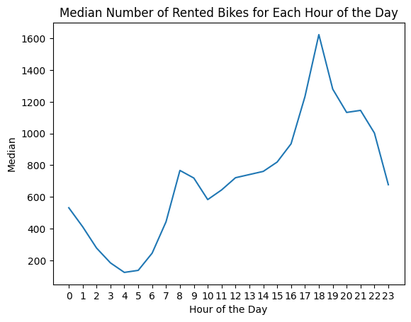

```python
df.groupby('Hour')['Rented Bike Count'].median().plot.line(rot=0)
plt.title('Median Number of Rented Bikes for Each Hour of the Day')
plt.xlabel('Hour of the Day')
plt.ylabel('Median')
plt.xticks(range(0,24,1))
plt.show()
```

This line graph shows the median number of rented bikes for each hour of the day. We can see that there is generally a much higher median frequency during daytime hours, implied by the two peaks during 8AM and 6PM. During the night time, we can see the median frequency is much lower with 4-5AM having the smallest median of rented bikes. This agrees with our alternative hypothesis that median rented bike count is different in the daytime than it is at night time.

Finally, we will conduct another Mann-Whitney test to show the relationship between rented bike count and visibility along with some visualizations to see what’s happening.

## **Relationship Between Rented Bike Count and Visibility**

### **Mann-Whitney Test (a = 0.05)**

Ho: The number of rented bikes per hour under normal visibility (greater than or equal to 1000 *10m) is equal to the number of rented bikes under lower visibility (less than 1000* 10m).

Ha: The number of rented bikes per hour under normal visibility days is not equal to the number of rented bikes under lower visibility.

```python
from scipy.stats import mannwhitneyu

normal_visibility = df[df['Visibility (10m)'] >= 1000]

lower_visibility = df[df['Visibility (10m)'] < 1000]

stat, p = mannwhitneyu(normal_visibility['Rented Bike Count'], lower_visibility['Rented Bike Count'])

print("Median Number of Rented Bikes Under Normal Visibility:", df[df['Visibility (10m)'] >= 1000]['Rented Bike Count'].median())
print("Median Number of Rented Bikes Under Lower Visibility:", df[df['Visibility (10m)'] < 1000]['Rented Bike Count'].median())
print(f'Mann-Whitney U statistic: {stat}')
print(f'p-value: {p}')
```

```
Median Number of Rented Bikes Under Normal Visibility: 642.0
Median Number of Rented Bikes Under Lower Visibility: 342.5
Mann-Whitney U statistic: 8976552.0
p-value: 1.3469959624273748e-77
```

The p-value is much smaller than the alpha level of 0.05, indicating that there is a statistically significant difference in the number of rented bikes between days with normal visibility (defined here as visibility at or above 10000 meters) and days with lower visibility (defined as visibility below 10000 meters). In other words, the test results suggest that the number of rented bike counts per hour under normal visibility is significantly different from the distribution of rented bikes per hour under lower visibility. This implies that visibility could indeed affect the number of bikes rented per hour.

Let's make some visualizations to show our results from our Mann-Whitney test.

### **Visualizations**

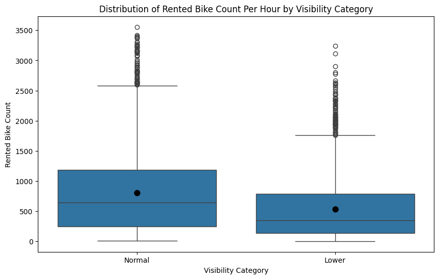

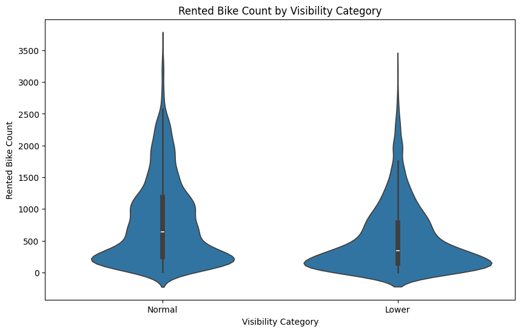

```python
df['Visibility Category'] = ['Normal' if x >= 1000 else 'Lower' for x in df['Visibility (10m)']]

plt.figure(figsize=(10, 6))
sns.boxplot(x='Visibility Category', y='Rented Bike Count', data=df)
sns.pointplot(x='Visibility Category', y='Rented Bike Count', data=df, errorbar=('ci', 95), linestyle='none', color='black')
plt.title('Distribution of Rented Bike Count Per Hour by Visibility Category')
plt.ylabel('Rented Bike Count')
plt.xlabel('Visibility Category')
plt.show()

plt.figure(figsize=(10, 6))
sns.violinplot(x='Visibility Category', y='Rented Bike Count', data=df)
plt.title('Rented Bike Count by Visibility Category')
plt.ylabel('Rented Bike Count')
plt.xlabel('Visibility Category')
plt.show()

df = df.drop('Visibility Category', axis=1)
```

The violin and box plots provided illustrate the distribution of rented bike counts under different visibility conditions. The violin plot reveals that the distribution for normal visibility is broader with a higher density around the median, suggesting that higher bike counts are more common when visibility is good. The "Lower" visibility category, on the other hand, has a more tapered distribution, which suggests a narrower range of bike counts around the median. In the violin plots, the kernel density estimation on each side of the gray line (which represents the median) shows the distribution shape of the rented bike counts. The wider sections of the violin plot indicate a higher probability density, meaning it is more likely for members of the population (rented bike counts) to have values in that range. Conversely, the skinnier sections represent a lower probability density, indicating it is less likely for the rented bike counts to fall within those ranges. The box plot supports the visualization made by the violin plot, showing a higher median rented bike count for normal visibility compared to lower visibility, with a larger interquartile range indicating greater variability on days with normal visibility. Both plots display outliers, indicating occasional days with unusually high bike counts in both visibility categories.

# **Conclusions from Exploratory Analysis**

The analysis of the Seoul Bike Sharing Demand dataset reveals that bike rental demand is significantly influenced by seasonal changes, time of day, and weather conditions, particularly visibility. Given the presence of outliers and overrepresented features like rainfall and snowfall, a sophisticated regression modeling approach, such as linear regression, random forests, or gradient boosting, is recommended to accurately predict hourly bike rental demand. While linear regression can capture the overall trends and relationships between the features and the target variable, random forests and gradient boosting are preferred due to their ability to handle complex, non-linear relationships and outliers, which are inherent in the dataset. The insights indicate that bike rental patterns are not only subject to typical daily fluctuations, with higher demand during daytime and specific peak hours, but also to environmental factors and seasonal variations, underscoring the necessity for a predictive model that can adeptly navigate these dynamics to optimize bike fleet management and enhance user satisfaction in Seoul's bike-sharing system. The choice of random forests or gradient boosting is further justified by their robustness to outliers, capability to model non-linear relationships, and provision of insights into feature importance, which are crucial for understanding and predicting the nuanced patterns of bike rental demand. Moreover, their flexibility and adaptability make them suitable for the dataset's mix of continuous and categorical variables, and their proven prediction accuracy ensures that they can effectively meet the challenges presented by the Seoul Bike Sharing Demand dataset, thereby supporting efficient bike fleet management and improving user experience. However, linear regression remains a valuable baseline model that can provide interpretable coefficients and help identify the overall impact of each feature on the bike rental demand.

# **4. Primary Analysis**

Let’s now hop into our primary analysis. We will first apply feature engineering to prepare our data for machine learning.

## **Feature Engineering**

To start off, notice that some of our columns like Holiday, Hour, Month, and Weekday are categorical variables. To utilize these features, we have to apply one hot encoding to transform them into numerical values for our model. We will also drop irrelevant columns like Year, Day, and Seasons. This is because the patterns in Rental Bike Count from these columns are sufficiently accounted for with the Month column. It provides information more frequently than on a yearly basis; days of the month only offers redundant information on what kind of day it is (holiday, weekday, etc.); seasons depend on the time of year or in other words what month it is.

```python
# Applying one-hot encoding to categorical variables and dropping irrelevant columns
df2 = pd.get_dummies(df, columns=['Holiday', 'Hour', 'Month', 'Weekday'])
df2 = df2.drop(columns=['Year', 'Day', 'Seasons'])
df2 = df2.astype(int)
```

To ensure our data is scaled similarly, we can apply log transformations.

```python
# Applying log transformations
df2['Rented Bike Count'] = (df2['Rented Bike Count'] - df2['Rented Bike Count'].min() + 1).transform(np.log)
df2['Temperature(°C)'] = (df2['Temperature(°C)'] - df2['Temperature(°C)'].min() + 1).transform(np.log)
df2['Humidity(%)'] = (df2['Humidity(%)'] - df2['Humidity(%)'].min() + 1).transform(np.log)
df2['Wind speed (m/s)'] = (df2['Wind speed (m/s)'] - df2['Wind speed (m/s)'].min() + 1).transform(np.log)
df2['Visibility (10m)'] = (df2['Visibility (10m)'] - df2['Visibility (10m)'].min() + 1).transform(np.log)
df2['Dew point temperature(°C)'] = (df2['Dew point temperature(°C)'] - df2['Dew point temperature(°C)'].min() + 1).transform(np.log)
df2['Solar Radiation (MJ/m2)'] = (df2['Solar Radiation (MJ/m2)'] - df2['Solar Radiation (MJ/m2)'].min() + 1).transform(np.log)
df2['Rainfall(mm)'] = (df2['Rainfall(mm)'] - df2['Rainfall(mm)'].min() + 1).transform(np.log)
df2['Snowfall (cm)'] = (df2['Snowfall (cm)'] - df2['Snowfall (cm)'].min() + 1).transform(np.log)
```

## **Linear Regression**

We will now create a linear regression model to help us predict the number of rented bikes based on the different features we are looking at. Our X or independent variables will be everything except “rented bike count.” These are the variables that our linear regression model will use to predict our Y or dependent variable, which is “rented bike count.”

```python
# Determining what are the features (X) and the target label (y) are from the dataset.
X = df2.drop(columns=['Rented Bike Count'])
y = df2['Rented Bike Count']
```

Next let’s split our data into training and testing sets, scale our feature sets, and train our model using linear regression.

```python
# Spliting the data into training and testing sets
X_train, X_test, y_train, y_test = train_test_split(X, y, test_size=0.2, random_state=42)
```

```python
# Standardizing the feature sets (both X_train and X_test)
scaler = StandardScaler()
X_train = scaler.fit_transform(X_train)
X_test = scaler.transform(X_test)
```

```python
# Training the model using the training data
linear_reg = LinearRegression()
linear_reg.fit(X_train, y_train)

# Predicting on the model
train_pred = linear_reg.predict(X_train)
test_pred = linear_reg.predict(X_test)
```

Now that our model is trained, let’s look at its performance. The MSE values for both training and testing data are relatively close, which suggests that the model generalizes well to unseen data. They are not extremely low, but they are reasonable, indicating that the model's predictions are approximately close to the actual values. The R2 scores suggests that the model captures a majority of the variability in the data. Overall, there is still room for improvement. This will be evident with our Random Forest model.

```python
# Printing mean squared errors and r^2 scores
print("Training Data:")
print("MSE:", mean_squared_error(y_train, train_pred))
print("R2 Score:", r2_score(y_train, train_pred))
print()

mse = mean_squared_error(y_test, test_pred)
r2 = r2_score(y_test, test_pred)
print("Testing Data:")
print("MSE:", mse)
print("R2 Score:", r2)
```

```
Training Data:
MSE: 0.340665919576707
R2 Score: 0.7577209573254893

Testing Data:
MSE: 0.3026769487095612
R2 Score: 0.7605512233210799
```

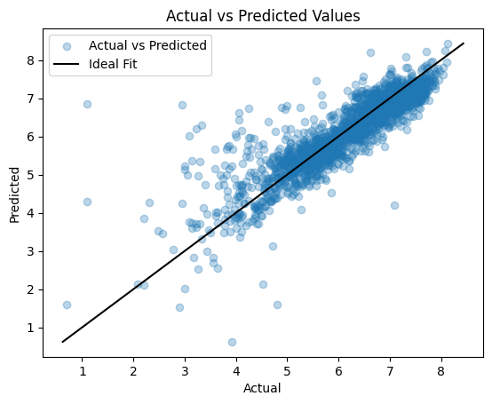

```python
# Evaluate the performance of the model
plt.scatter(y_test, test_pred, alpha=0.3, label='Actual vs Predicted')
p1 = max(max(test_pred), max(y_test))
p2 = min(min(test_pred), min(y_test))
plt.plot([p1, p2], [p1, p2], color='black', label='Ideal Fit')
plt.xlabel('Actual')
plt.ylabel('Predicted')
plt.title('Actual vs Predicted Values')
plt.legend()
plt.show()
```

Using the Linear Regression model, we can roughly predict the number of bikes that will be rented out given specific conditions. In this way, we can forecast bike rental demand for future events and/or seasonal changes. This can assist in planning inventory and improving the efficiency of bike rental operations such as adjusting pricing strategies, optimizing bike distribution across stations, and scheduling maintenance activities based on predicted demand.

With our linear regression model, we can create another model that utilizes random forest regression and compare their performances.

## **Random Forest Regression**

Like for linear regression, we will split our variables to determine what are the features (X) and the target label (y) from the dataset, split our training and testing sets, scale our features, and train our model. We will use the same setup and hot encoding we used for our linear regression to do the split. Then we repeat the same steps as our other models where we separate our features and target label, split our data into training and test, scale our features, and train our model.

```python
Xrf = df2.drop(columns=['Rented Bike Count'])
yrf = df2['Rented Bike Count']

Xrf_train, Xrf_test, yrf_train, yrf_test = train_test_split(Xrf, yrf, test_size=0.2, random_state=42)
```

Then we initialize and train the random forest regression model. The n_esimators parameter is where we adjust the number of decision trees you will be running in the model. Here we will be running 100 decision trees. Setting a 100 trees provides a good balance between model performance and computational complexity. Using too few trees may limit the model's ability to capture complex patterns, while using an excessively large number of trees can lead to overfitting and significantly increase training time without substantial gains in accuracy. We then set random_state to 42 to ensure that the same randomization is used each time we run the code, resulting in the same splits of the data.

```python
rf = RandomForestRegressor(n_estimators=100, random_state=42)

rf.fit(Xrf_train, yrf_train)
```

```
RandomForestRegressor(random_state=42)
```

We then predict() the test set using the predict function and calculate the mean squared error (MSE) and the $r^{2}$ score. MSE and $r^{2}$ are used together to evaluate regression models because they provide complementary information about model fit and performance . MSE gives an absolute measure of error, while $r^{2}$ provides a relative measure of the proportion of variance explained by the model.

When looking at the performance of our random forest regression model, we can see its performance is slightly better than our linear regression model. The mean squared error is lower and the R^2 score is closer to 1.

```python
yrf_pred = rf.predict(Xrf_test)
mse_test = mean_squared_error(yrf_test, yrf_pred)
r2_test = r2_score(yrf_test, yrf_pred)

print(f"Mean Squared Error: {mse_test}")
print(f"R^2 Score: {r2_test}")
```

```
Mean Squared Error: 0.1637788495116745
R^2 Score: 0.8704339880237051
```

We test and predicted values to visualize how accurate our model is. When looking at the random forest regression model's performance, we can see the points are closely aligned to the estimated regression line (the diagonal line in the graph). Now that we graphed our graph comparing actual vs predicted values. We can then proceed to also look at the feature importance for this model, which is also similiar to our random forest regression model.

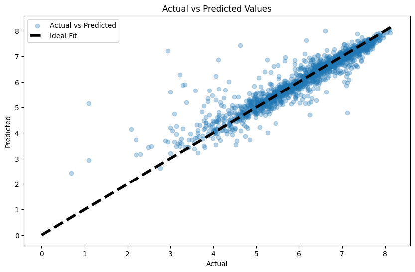

```python
import matplotlib.pyplot as plt
plt.figure(figsize=(10, 6))
plt.scatter(yrf_test, yrf_pred, alpha=0.3, label='Actual vs Predicted')
plt.plot([yrf.min(), yrf.max()], [yrf.min(), yrf.max()], 'k--', lw=4, label='Ideal Fit')
plt.xlabel('Actual')
plt.ylabel('Predicted')
plt.title('Actual vs Predicted Values')
plt.legend()
plt.show()
```

One cool feature about random forest regression is that we can see the feature importance. This will help show us which features play the biggest role in helping to predict the number of rented bikes. Let’s make a plot to visualize the feature importance in our random forest model.

```python
importances_rf = rf.feature_importances_
```

```python
# Create a DataFrame to visualize the feature importances
features_rf = Xrf.columns
importance_rf = pd.DataFrame({'Feature': features_rf, 'Importance': importances_rf}).sort_values(by='Importance', ascending=False)
```

We then create a dataframe to visualize the feature importances. This is a crucial step in creating a bar graph for visualizing feature importances in the random forest regression model.

```
WARNING:matplotlib.legend:No artists with labels found to put in legend.  Note that artists whose label start with an underscore are ignored when legend() is called with no argument.
```

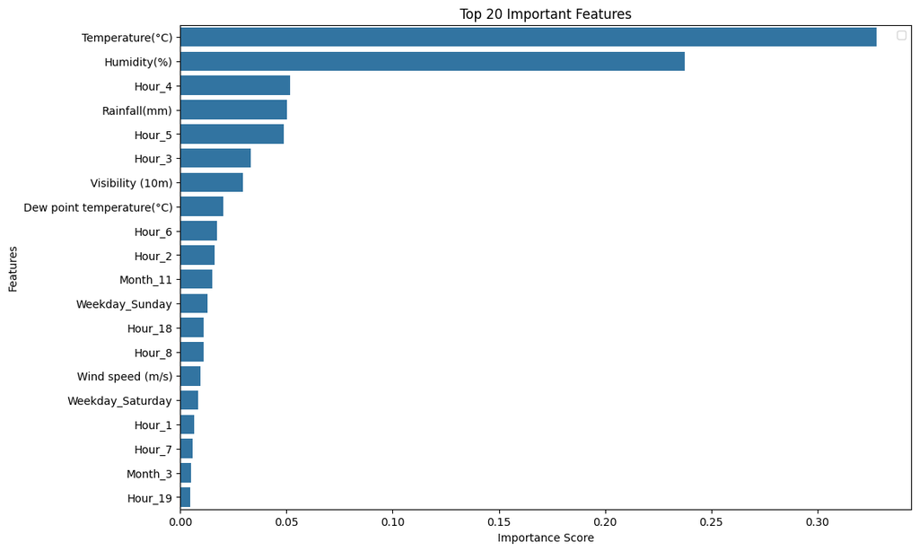

```python
# Plot feature importance
plt.figure(figsize=(12, 8))
sns.barplot(x='Importance', y='Feature', data=importance_rf.head(20))
plt.title('Top 20 Important Features')
plt.xlabel('Importance Score')
plt.ylabel('Features')
plt.legend()
plt.show()
```

For our final model, we will apply gradient boosting regression.

## **Gradient Boosting Regression**

We continue to use the same setup and hot encoding we used for our linear regression and random forest regression models. We use that setup to determine what are the features (X) and the target label (y) are from the dataset. Then we repeat the same steps as our other models where we separate our features and target label, split our data into training and test, scale our features, and train our model.

```python
Xgb = df2.drop(columns=['Rented Bike Count'])
ygb = df2['Rented Bike Count']

Xgb_train, Xgb_test, ygb_train, ygb_test = train_test_split(Xgb, ygb, test_size=0.2, random_state=42)
```

Then we initialize and train the gradient boosting regression model. The n_esimators parameter is where we adjust the number of decision trees you will be running in the model. We then set random_state to 42 to ensure that the same randomization is used each time we run the code, resulting in the same splits of the data.

```python
gb = GradientBoostingRegressor(n_estimators=100, random_state=42)

gb.fit(Xgb_train, ygb_train)
```

```
GradientBoostingRegressor(random_state=42)
```

We then predict() the test set using the predict function and calculate the mean squared error (MSE) and the $r^{2}$ score. MSE and $r^{2}$ are used together to evaluate regression models because they provide complementary information about model fit and performance . MSE gives an absolute measure of error, while $r^{2}$ provides a relative measure of the proportion of variance explained by the model.

When looking at the performance of our random forest regression model, we can see its performance is slightly better than our linear regression model. While the performance is not as high as the random forest model, the mean squared error is still low and the R^2 score is closer to 1 where the model is shown to be reliable in predicting rental bike demand.

```python
ygb_pred = gb.predict(Xgb_test)

mse_gb = mean_squared_error(ygb_test, ygb_pred)
r2_gb = r2_score(ygb_test, ygb_pred)

print(f"Mean Squared Error: {mse_gb}")
print(f"R^2 Score: {r2_gb}")
```

```
Mean Squared Error: 0.21430818270415072
R^2 Score: 0.830460058489514
```

We then visualize the results. This visualization will help us see how closely the predicted values align with the actual values. The closer the points are to the diagonal line known as the estimated regression line, the better the predictions.

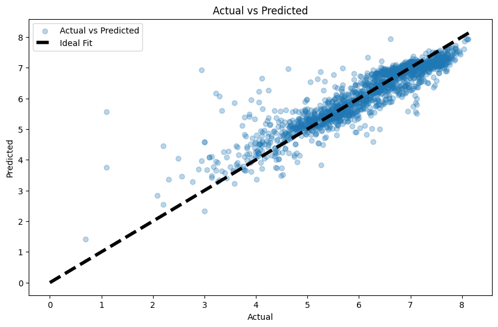

```python
plt.figure(figsize=(10, 6))
plt.scatter(ygb_test, ygb_pred, alpha=0.3, label='Actual vs Predicted')
plt.plot([ygb.min(), ygb.max()], [ygb.min(), ygb.max()], 'k--', lw=4, label='Ideal Fit')
plt.xlabel('Actual')
plt.ylabel('Predicted')
plt.title('Actual vs Predicted')
plt.legend()
plt.show()
```

When looking at its performance, we can see it is very similar to our random forest regression model. We can see the points are tightly clustered to the estimated regression line illustrating the model's ability to reliably predict rental bike demand in Seoul. We can then proceed to also look at the feature importance for this model, which is also similiar to our random forest regression model.

```python
importances_gb = gb.feature_importances_
```

We then create a dataFrame to visualize the feature importances. This is a crucial step in creating a bar graph for visualizing feature importances in the gradient boosting regression model.

```python
features_gb = Xgb.columns
importance_gb = pd.DataFrame({'Feature': features_gb, 'Importance': importances_gb}).sort_values(by='Importance', ascending=False)
```

We can now visualize the the feature importances of the gradient boosting regression model. As we can see, gradient boosting model shares the top 6 most influential predictors with the random forest model.

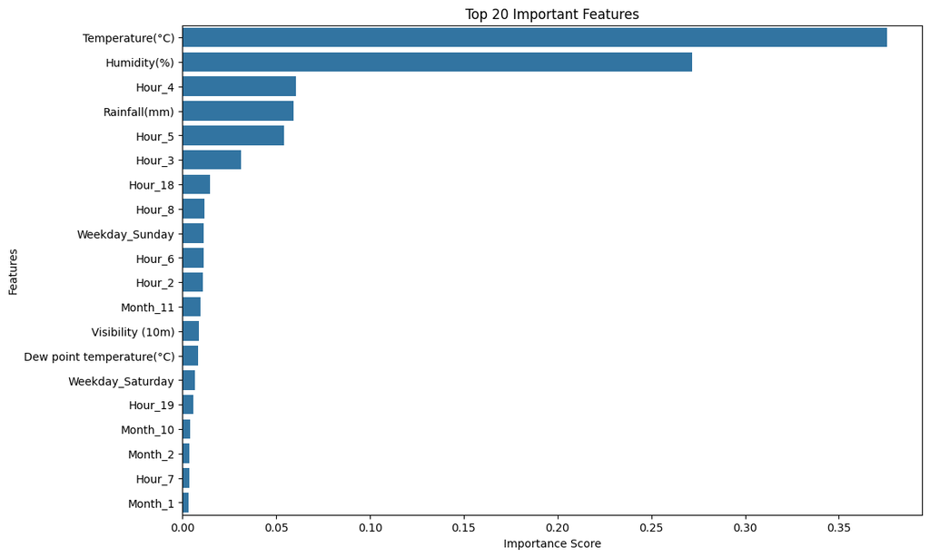

```python
plt.figure(figsize=(12, 8))
sns.barplot(x='Importance', y='Feature', data=importance_gb.head(20))
plt.title('Top 20 Important Features')
plt.xlabel('Importance Score')
plt.ylabel('Features')
plt.legend
plt.show()
```

# **5. Insights and Conclusions**

In conclusion, this project was an analysis of bike rental demand in Seoul, South Korea, with the aim of understanding the factors influencing bike rental demand and developing predictive models to forecast bike rental demand accurately.

Our exploratory analysis revealed significant correlations between bike rental count and factors like seasons, time of day, and visibility. Using statistical tests such as the Kruskal-Wallis test and Mann-Whitney U test, we validated our conclusions regarding the impact of these factors on bike rental counts. These tests provided strong evidence supporting our findings and highlighted the importance of considering these factors in predicting bike rental demand accurately.

Building on our exploratory analysis, we developed predictive models using linear regression and random forest regression techniques. While our linear regression model provided a baseline understanding of the relationships between features and bike rental count, our random forest regression model offered superior predictive performance. These models have the potential to assist bike rental operators in optimizing inventory management, pricing strategies, and operational decisions to meet demand efficiently.

The Random Forest Regression model and the Gradient Boosting Regression model has demonstrated strong predictive performance on the Seoul Bike Sharing dataset, with a Mean Squared Error of 0.1637788495116745 and an $r^{2}$ Score of 0.8704339880237051 for random forest and Mean Squared Error of 0.21430818270415072 and an $r^{2}$ Score of 0.830460058489514 for gradient boosting, indicating their ability to accurately forecast bike rental demand based on factors such as weather conditions, time of day, and day of the week. The graphs of each respective model also show that many of the points are concentrated near the estimated regression line indicating the random forest and gradient boosting regression models fit the data well and the models' predictions are quite accurate. By leveraging the feature importance insights provided by the model, bike rental operators can optimize bike distribution across stations, adjust pricing strategies, schedule maintenance activities, and communicate expected bike availability to customers, ultimately transforming their operations by enabling data-driven decision-making and improving overall efficiency.

We notice that after running feature importances on both the random forest and gradient boosting regression models that temperature, humidity, and rainfall are some of the biggest factors in predicting bike rental demand Seoul, South Korea. While both regression models provide the similar insights into most influential predictors, the feature importance measures differ between the two methods. Random Forest uses a measure called Mean Decrease in Impurity (MDI), which is based on the decrease in node impurity weighted by the probability of reaching that node. Gradient Boosting, on the other hand, can use various feature importance measures, such as Gain (the improvement in loss function brought by a feature) and Cover (the number of samples affected by a feature) all of which are then averaged across all trees in the model to calculate feature importance. Since both the random forest regression model and the gradient boosting regression model indicate the similar results, we can reliably say that temperature, humidity, and rainfall are the most influential predictors of Seoul's bike renting demand.

Overall, we can use this data and analysis to provide Seoul with more information about the number of rented bikes they may expect to have in a given day based on various factors like temperature, humidity, and the day of the week. This can help Seoul create a more efficient bike program for everyone in the city to use.

# **For Further Reading**

## Data Processing

- For Beginners: "Data Preprocessing in Data Mining" on GeeksforGeeks provides a comprehensive introduction to the initial steps of data processing, including cleaning, transformation, and reduction. [GeeksforGeeks - Data Preprocessing](https://www.geeksforgeeks.org/data-preprocessing-in-data-mining/)
- For Advanced Readers: "Feature Engineering for Machine Learning" by Alice Zheng and Amanda Casari offers in-depth insights into transforming raw data into features that better represent the underlying problem to the predictive models, enhancing model accuracy on unseen data. [O'Reilly - Feature Engineering for Machine Learning](https://www.oreilly.com/library/view/feature-engineering-for/9781491953235/)

## Exploratory Data Analysis (EDA)

- For Beginners: "Exploratory Data Analysis" on Kaggle Learn provides a practical introduction to EDA techniques using Python and Jupyter Notebooks. [Kaggle - Exploratory Data Analysis](https://www.kaggle.com/learn/exploratory-data-analysis)
- For Advanced Readers: "Exploratory Data Analysis with R" by Roger D. Peng offers a deeper dive into EDA techniques, focusing on the R programming language. [Leanpub - Exploratory Data Analysis with R](https://leanpub.com/exdata)

## Hypothesis Testing Intuition

- For Beginners: Khan Academy's "Hypothesis Testing and P-values" video tutorial provides a clear and intuitive explanation of hypothesis testing and the concept of p-values. [Khan Academy - Hypothesis Testing and P-values](https://www.khanacademy.org/math/statistics-probability/significance-tests-one-sample)
- For Advanced Readers: "Statistical Inference" by Casella and Berger is a comprehensive textbook that covers various aspects of hypothesis testing in depth, suitable for readers with a strong mathematical background. [Amazon - Statistical Inference](https://www.amazon.com/Statistical-Inference-George-Casella/dp/0534243126)

## Machine Learning

- For Beginners: "Machine Learning" by Andrew Ng on Coursera provides a broad introduction to machine learning, data mining, and statistical pattern recognition. [Coursera - Machine Learning](https://www.coursera.org/learn/machine-learning)
- For Advanced Readers: "The Elements of Statistical Learning" by Hastie, Tibshirani, and Friedman dives deep into the models, theory, and algorithms in machine learning for readers with a strong foundation in statistics and mathematics. [Springer - The Elements of Statistical Learning](https://web.stanford.edu/~hastie/ElemStatLearn/)

## Linear Regression

- For Beginners: The "Regression Tutorial" on Stat Trek offers an easy-to-understand introduction to linear regression, covering both simple and multiple regression. [Stat Trek - Regression Tutorial](https://stattrek.com/tutorials/regression-tutorial)
- For Advanced Readers: "Linear Regression Analysis" on PMC - NCBI provides a detailed exploration of linear regression, including univariable and multivariable models. [PMC - NCBI - Linear Regression Analysis](https://www.ncbi.nlm.nih.gov/pmc/articles/PMC2992018/)

## Random Forest Regression

- For Beginners: "Random Forest in Python" on Towards Data Science provides a practical guide to implementing Random Forest regression using Python. [Towards Data Science - Random Forest in Python](https://towardsdatascience.com/random-forest-in-python-24d0893d51c0)
- For Advanced Readers: "The Elements of Statistical Learning" by Hastie, Tibshirani, and Friedman covers Random Forests in the context of ensemble methods, offering a theoretical perspective. [Springer - The Elements of Statistical Learning](https://web.stanford.edu/~hastie/ElemStatLearn/)

## Gradient Boosting Regression

- For Beginners: "A Gentle Introduction to Gradient Boosting" on Machine Learning Mastery provides an accessible overview of the Gradient Boosting algorithm for regression and classification. [Machine Learning Mastery - A Gentle Introduction to Gradient Boosting](https://machinelearningmastery.com/gentle-introduction-gradient-boosting-algorithm-machine-learning/)
- For Advanced Readers: "Gradient Boosting Machines, A Tutorial" on Frontiers in Neurorobotics offers a comprehensive and in-depth look at Gradient Boosting Machines, including theory and applications. [Frontiers in Neurorobotics - Gradient Boosting Machines, A Tutorial](https://www.frontiersin.org/articles/10.3389/fnbot.2013.00021/full)